# Baseline Gambling Simulations

Nick Kurtansky

11/25/2017

I will run this simulation seperately for each of the years from 2001 through 2017 in order to look for trends that may provide insight in how the oddsmakers have adapted over the years.

### load in data

```r
load("data/favorite.data.RData")
data <- favorite.data

#head(data,100)
#str(data)
```

### Clean Data

```r
# only include matches that sports books took bets on
data <- data %>% filter((FcountOdds > 0) & (UcountOdds > 0))

# only include matches between players who have a rank
data <- data %>% filter((!is.na(URank))&(!is.na(FRank)))

# new column for absolute rank difference variable: rank.dif
data <- data %>% mutate(rank.dif = URank - FRank)

# new column for absolute odds difference variable: odds.dif
data <- data %>% mutate(abs.odds.dif = avgU - avgF)

str(data)
```

```
## 'data.frame':    45641 obs. of  48 variables:
##  $ ATP         : int  1 1 1 1 1 1 1 1 1 1 ...
##  $ Location    : chr  "Adelaide" "Adelaide" "Adelaide" "Adelaide" ...
##  $ Tournament  : chr  "AAPT Championships" "AAPT Championships" "AAPT Championships" "AAPT Championships" ...
##  $ Series      : chr  "International" "International" "International" "International" ...
##  $ Court       : chr  "Outdoor" "Outdoor" "Outdoor" "Outdoor" ...
##  $ Surface     : chr  "Hard" "Hard" "Hard" "Hard" ...
##  $ Round       : chr  "1st Round" "1st Round" "2nd Round" "2nd Round" ...
##  $ Best.of     : Factor w/ 2 levels "3","5": 1 1 1 1 1 1 1 1 1 1 ...
##  $ year        : num  2001 2001 2001 2001 2001 ...
##  $ maxWinOdds  : num  1.12 1.28 1.35 1.13 2.7 1.55 2.3 1.47 2 1.41 ...
##  $ minLoseOdds : num  3.5 3.3 2.6 5.5 1.41 2 1.5 2.2 1.61 2.1 ...
##  $ date.new    : Date, format: "2001-01-01" "2001-01-01" ...
##  $ rank.upset  : logi  FALSE FALSE FALSE FALSE TRUE FALSE ...
##  $ maxProfit   : num  0.12 0.28 0.35 0.13 1.7 ...
```

[output cut: 34 more lines]

```r
#data %>% filter(year == 2008)
```

### What is the raw probability of an upset?

```r
sum(data$odds.upset/nrow(data))
```

```
## [1] 0.2999496
```

Upset occurs with probability 0.2999496… Hence, odds have a success rate p = 0.7000504

# Simulations

#### Outcome Matrix

Includes: Year, strategy, net profit, wins, tries

```r
Year <- c(2001:2017)
B1 <- rep("bet fav - avg odds", times=17)
B2 <- rep("bet dog - avg odds", times=17)
B3 <- rep("bet random - avg odds", times=17)
B4 <- rep("bet higher rank - avg odds", times=17)
B5 <- rep("bet lower rank - avg odds",times=17)
B6 <- rep("bet fav - best odds", times=17)
B7 <- rep("bet dog - best odds", times=17)
B8 <- rep("bet random - best odds", times=17)
B9 <- rep("bet higher rank - best odds", times=17)
B10 <- rep("bet lower rank - best odds",times=17)
Net <- rep(NA, times=17)
Wins <- rep(NA, times=17)
Tries <- rep(NA, times=17)

df1 <- data.frame(Year, B1, Net, Wins, Tries)
df2 <- data.frame(Year, B2, Net, Wins, Tries)
df3 <- data.frame(Year, B3, Net, Wins, Tries)
df4 <- data.frame(Year, B4, Net, Wins, Tries)
df5 <- data.frame(Year, B5, Net, Wins, Tries)
df6 <- data.frame(Year, B6, Net, Wins, Tries)
df7 <- data.frame(Year, B7, Net, Wins, Tries)
df8 <- data.frame(Year, B8, Net, Wins, Tries)
df9 <- data.frame(Year, B9, Net, Wins, Tries)
df10 <- data.frame(Year, B10, Net, Wins, Tries)
```

## Baseline Strategy 1: always bet favorite average book

#### Function for single-year simulation

```r
bet.favorite <- function(df, wager = 10){
  # initialize
  net <- 0
  tries <- 0
  wins <- 0

  # for each match:
  for(i in 1:nrow(df)){

    # if chalk (win)
    if(df$odds.upset[i] == FALSE){
      bet.result <- wager * (df$avgF[i]-1)

      net <- net + bet.result
      wins <- wins + 1
      tries <- tries + 1
    }

    # if upset (loss)
    if(df$odds.upset[i] == TRUE){
      bet.result <- -1*wager

      net <- net + bet.result
      tries <- tries + 1
    }
  }

  # output a list
  out <- list(net, wins, tries)
  names(out) <- c("net","wins","tries")
  return(out)
}
```

#### Loop through all the seasons

```r
for(i in 1:length(Year)){
  season <- data %>% filter(year == Year[i])
  s.result <- bet.favorite(season, wager = 10)

  df1$Net[i] <- s.result[[1]]
  df1$Wins[i] <- s.result[[2]]
  df1$Tries[i] <- s.result[[3]]
}
names(df1)[2] <- "Strategy"
df1
```

```
##    Year           Strategy        Net Wins Tries
## 1  2001 bet fav - avg odds -1009.6550 1709  2528
## 2  2002 bet fav - avg odds -1043.7155 1802  2665
## 3  2003 bet fav - avg odds -1095.8972 1941  2798
## 4  2004 bet fav - avg odds -1113.3762 1902  2801
## 5  2005 bet fav - avg odds  -789.7327 2037  2880
## 6  2006 bet fav - avg odds -1427.8592 1969  2857
## 7  2007 bet fav - avg odds  -583.0478 1979  2764
## 8  2008 bet fav - avg odds  -892.7123 1880  2669
## 9  2009 bet fav - avg odds -1474.3160 1902  2705
## 10 2010 bet fav - avg odds  -819.9862 1885  2658
## 11 2011 bet fav - avg odds  -600.0690 1922  2664
## 12 2012 bet fav - avg odds  -960.4873 1866  2597
## 13 2013 bet fav - avg odds -1532.6058 1830  2621
## 14 2014 bet fav - avg odds  -891.3977 1840  2596
## 15 2015 bet fav - avg odds  -999.7758 1858  2616
## 16 2016 bet fav - avg odds  -887.9158 1861  2615
## 17 2017 bet fav - avg odds -1750.0375 1768  2607
```

## Baseline Strategy 2: always bet underdog (average book)

#### Function for single-year simulation

```r
bet.underdog <- function(df, wager = 10){
  # initialize
  net <- 0
  tries <- 0
  wins <- 0

  # for each match:
  for(i in 1:nrow(df)){

    # if upset (win)
    if(df$odds.upset[i] == TRUE){
      bet.result <- wager * (df$avgU[i]-1)

      net <- net + bet.result
      wins <- wins + 1
      tries <- tries + 1
    }

    # if chalk (loss)
    if(df$odds.upset[i] == FALSE){
      bet.result <- -1*wager

      net <- net + bet.result
      tries <- tries + 1
    }
  }

  # output a list
  out <- list(net, wins, tries)
  names(out) <- c("net","wins","tries")
  return(out)
}
```

#### Loop through all the seasons

```r
for(i in 1:length(Year)){
  season <- data %>% filter(year == Year[i])
  s.result <- bet.underdog(season, wager = 10)

  df2$Net[i] <- s.result[[1]]
  df2$Wins[i] <- s.result[[2]]
  df2$Tries[i] <- s.result[[3]]
}
names(df2)[2] <- "Strategy"
df2
```

```
##    Year           Strategy       Net Wins Tries
## 1  2001 bet dog - avg odds -5653.442  819  2528
## 2  2002 bet dog - avg odds -5384.058  863  2665
## 3  2003 bet dog - avg odds -5946.461  857  2798
## 4  2004 bet dog - avg odds -4534.097  899  2801
## 5  2005 bet dog - avg odds -5055.489  843  2880
## 6  2006 bet dog - avg odds -2878.299  888  2857
## 7  2007 bet dog - avg odds -3843.501  785  2764
## 8  2008 bet dog - avg odds -3357.882  789  2669
## 9  2009 bet dog - avg odds -3855.921  803  2705
## 10 2010 bet dog - avg odds -3903.482  773  2658
## 11 2011 bet dog - avg odds -4787.827  742  2664
## 12 2012 bet dog - avg odds -3687.795  731  2597
## 13 2013 bet dog - avg odds -2063.250  791  2621
## 14 2014 bet dog - avg odds -3451.587  756  2596
## 15 2015 bet dog - avg odds -3774.125  758  2616
## 16 2016 bet dog - avg odds -2709.933  754  2615
## 17 2017 bet dog - avg odds -1055.358  839  2607
```

## Baseline Strategy 3: random choice of underdog/favorite (average book)

#### Function for single-year simulation

```r
bet.random <- function(df, wager = 10){
  # initialize
  net <- 0
  tries <- 0
  wins <- 0

  # for each match:
  for(i in 1:nrow(df)){

    choice <- sample(c("fav","dog"),size=1)

    if(choice == "dog"){

      # if upset (win)
      if(df$odds.upset[i] == TRUE){
        bet.result <- wager * (df$avgU[i]-1)

        net <- net + bet.result

        wins <- wins + 1
        tries <- tries + 1
      }

      # if chalk (loss)
      if(df$odds.upset[i] == FALSE){
        bet.result <- -1*wager

        net <- net + bet.result
        tries <- tries + 1
      }
    }

    if(choice == "fav"){

      # if chalk (win)
      if(df$odds.upset[i] == FALSE){
        bet.result <- wager * (df$avgF[i]-1)

        net <- net + bet.result
        wins <- wins + 1
        tries <- tries + 1
      }

      # if upset (loss)
      if(df$odds.upset[i] == TRUE){
        bet.result <- -1*wager

        net <- net + bet.result
        tries <- tries + 1
      }
    }
  }

  # output a list
  out <- list(net, wins, tries)

  names(out) <- c("net","wins","tries")
  return(out)
}
```

#### Loop through all the seasons

```r
for(i in 1:length(Year)){
  season <- data %>% filter(year == Year[i])
  s.result <- bet.random(season, wager = 10)

  df3$Net[i] <- s.result[[1]]
  df3$Wins[i] <- s.result[[2]]
  df3$Tries[i] <- s.result[[3]]
}
names(df3)[2] <- "Strategy"
df3
```

```
##    Year              Strategy       Net Wins Tries
## 1  2001 bet random - avg odds -3902.214 1239  2528
## 2  2002 bet random - avg odds -2412.817 1370  2665
## 3  2003 bet random - avg odds -2793.771 1438  2798
## 4  2004 bet random - avg odds -2880.893 1402  2801
## 5  2005 bet random - avg odds -2251.115 1468  2880
## 6  2006 bet random - avg odds -2169.436 1428  2857
## 7  2007 bet random - avg odds -2109.516 1401  2764
## 8  2008 bet random - avg odds -2802.570 1309  2669
## 9  2009 bet random - avg odds -3507.556 1326  2705
## 10 2010 bet random - avg odds -2679.739 1304  2658
## 11 2011 bet random - avg odds -2663.784 1333  2664
## 12 2012 bet random - avg odds -1510.118 1322  2597
## 13 2013 bet random - avg odds -2350.462 1284  2621
## 14 2014 bet random - avg odds -1569.548 1314  2596
## 15 2015 bet random - avg odds -1322.011 1335  2616
## 16 2016 bet random - avg odds -1595.307 1322  2615
## 17 2017 bet random - avg odds -1776.563 1313  2607
```

More successful than betting all underdogs. Less successful than betting all favorites. We still lose money in the end.

## Baseline Strategy 4: always bet the higher ranked player (average book)

#### Function for single-year simulation

```r
bet.highrank <- function(df, wager = 10){
  # initialize
  net <- 0
  tries <- 0
  wins <- 0

  # for each match:
  for(i in 1:nrow(df)){

    if(df$rank.upset[i] == FALSE){

      # if 'chalk' and higher rank (win)
      if(df$odds.upset[i]==FALSE){
        bet.result <- wager * (df$avgF[i]-1)

        net <- net + bet.result
        wins <- wins + 1
        tries <- tries + 1
      }

      # if 'dog' and higher rank (win)
      if(df$odds.upset[i]==TRUE){
        bet.result <- wager * (df$avgU[i]-1)

        net <- net + bet.result
        wins <- wins + 1
        tries <- tries + 1
      }
    }

    if(df$rank.upset[i] == TRUE){

      # if 'chalk' and lower rank (loss)
      if(df$odds.upset[i] == FALSE){
        bet.result <- -1*wager

        net <- net + bet.result
        tries <- tries + 1
      }

      # if 'dog' and lower rank (loss)
      if(df$odds.upset[i] == TRUE){
        bet.result <- -1*wager

        net <- net + bet.result
        tries <- tries + 1
      }
    }
  }

  # output a list
  out <- list(net, wins, tries)
  names(out) <- c("net","wins","tries")
  return(out)
}
```

#### Loop through all the seasons

```r
for(i in 1:length(Year)){
  season <- data %>% filter(year == Year[i])
  s.result <- bet.highrank(season, wager = 10)

  df4$Net[i] <- s.result[[1]]
  df4$Wins[i] <- s.result[[2]]
  df4$Tries[i] <- s.result[[3]]
}
names(df4)[2] <- "Strategy"
df4
```

```
##    Year                   Strategy        Net Wins Tries
## 1  2001 bet higher rank - avg odds -2407.4358 1581  2528
## 2  2002 bet higher rank - avg odds -2261.4175 1676  2665
## 3  2003 bet higher rank - avg odds -2480.5517 1804  2798
## 4  2004 bet higher rank - avg odds -1667.1253 1785  2801
## 5  2005 bet higher rank - avg odds -1560.4670 1897  2880
## 6  2006 bet higher rank - avg odds -1742.6082 1860  2857
## 7  2007 bet higher rank - avg odds -1723.0253 1803  2764
## 8  2008 bet higher rank - avg odds -1220.5137 1780  2669
## 9  2009 bet higher rank - avg odds  -901.5477 1825  2705
## 10 2010 bet higher rank - avg odds -1390.1700 1764  2658
## 11 2011 bet higher rank - avg odds -1034.5940 1795  2664
## 12 2012 bet higher rank - avg odds -1153.9323 1756  2597
## 13 2013 bet higher rank - avg odds -1810.0642 1721  2621
## 14 2014 bet higher rank - avg odds  -601.1227 1763  2596
## 15 2015 bet higher rank - avg odds  -809.7008 1774  2616
## 16 2016 bet higher rank - avg odds -1149.6408 1755  2615
## 17 2017 bet higher rank - avg odds -1698.2958 1692  2607
```

## Baseline Strategy 5: always bet the lower ranked player (average book)

#### Function for single-year simulation

```r
bet.lowrank <- function(df, wager = 10){
  # initialize
  net <- 0
  tries <- 0
  wins <- 0

  # for each match:
  for(i in 1:nrow(df)){

    # if 'chalk' and lower rank (win)
    if((df$rank.upset[i] == TRUE)&(df$odds.upset[i]==FALSE)){
      bet.result <- wager * (df$avgF[i]-1)

      net <- net + bet.result
      wins <- wins + 1
      tries <- tries + 1
    }

    # if 'dog' and lower rank (win)
    if((df$rank.upset[i] == TRUE)&(df$odds.upset[i]==TRUE)){
      bet.result <- wager * (df$avgU[i]-1)

      net <- net + bet.result
      wins <- wins + 1
      tries <- tries + 1
    }

    # if 'chalk' and higher rank (loss)
    if((df$rank.upset[i] == FALSE)&(df$odds.upset[i] == FALSE)){
      bet.result <- -1*wager

      net <- net + bet.result
      tries <- tries + 1
    }

    # if 'dog' and higher rank (win)
    if((df$rank.upset[i] == FALSE)&(df$odds.upset[i] == TRUE)){
      bet.result <- -1*wager

      net <- net + bet.result
      tries <- tries + 1
    }
  }

  # output a list
  out <- list(net, wins, tries)
  names(out) <- c("net","wins","tries")
  return(out)
}
```

#### Loop through all the seasons

```r
for(i in 1:length(Year)){
  season <- data %>% filter(year == Year[i])
  s.result <- bet.lowrank(season, wager = 10)

  df5$Net[i] <- s.result[[1]]
  df5$Wins[i] <- s.result[[2]]
  df5$Tries[i] <- s.result[[3]]
}
names(df5)[2] <- "Strategy"
df5
```

```
##    Year                  Strategy       Net Wins Tries
## 1  2001 bet lower rank - avg odds -4255.662  947  2528
## 2  2002 bet lower rank - avg odds -4166.356  989  2665
## 3  2003 bet lower rank - avg odds -4561.807  994  2798
## 4  2004 bet lower rank - avg odds -3980.348 1016  2801
## 5  2005 bet lower rank - avg odds -4284.755  983  2880
## 6  2006 bet lower rank - avg odds -2563.550  997  2857
## 7  2007 bet lower rank - avg odds -2703.524  961  2764
## 8  2008 bet lower rank - avg odds -3030.081  889  2669
## 9  2009 bet lower rank - avg odds -4428.689  880  2705
## 10 2010 bet lower rank - avg odds -3333.298  894  2658
## 11 2011 bet lower rank - avg odds -4353.302  869  2664
## 12 2012 bet lower rank - avg odds -3494.350  841  2597
## 13 2013 bet lower rank - avg odds -1785.792  900  2621
## 14 2014 bet lower rank - avg odds -3741.862  833  2596
## 15 2015 bet lower rank - avg odds -3964.200  842  2616
## 16 2016 bet lower rank - avg odds -2448.208  860  2615
## 17 2017 bet lower rank - avg odds -1107.100  915  2607
```

It makes sence that you wouldn’t be successsful always putting your money on the lower ranked player.

## Baseline Strategy 6: always bet favorite (highest book)

#### Function for single-year simulation

```r
bet.favorite.h <- function(df, wager = 10){
  # initialize
  net <- 0
  tries <- 0
  wins <- 0

  # for each match:
  for(i in 1:nrow(df)){

    # if chalk (win)
    if(df$odds.upset[i] == FALSE){
      bet.result <- wager * (df$FMaxOdds[i]-1)

      net <- net + bet.result
      wins <- wins + 1
      tries <- tries + 1
    }

    # if upset (loss)
    if(df$odds.upset[i] == TRUE){
      bet.result <- -1*wager

      net <- net + bet.result
      tries <- tries + 1
    }
  }

  # output a list
  out <- list(net, wins, tries)
  names(out) <- c("net","wins","tries")
  return(out)
}
```

#### Loop through all the seasons

```r
for(i in 1:length(Year)){
  season <- data %>% filter(year == Year[i])
  s.result <- bet.favorite.h(season, wager = 10)

  df6$Net[i] <- s.result[[1]]
  df6$Wins[i] <- s.result[[2]]
  df6$Tries[i] <- s.result[[3]]
}
names(df6)[2] <- "Strategy"
df6
```

```
##    Year            Strategy      Net Wins Tries
## 1  2001 bet fav - best odds  -192.79 1709  2528
## 2  2002 bet fav - best odds  -197.50 1802  2665
## 3  2003 bet fav - best odds  -189.55 1941  2798
## 4  2004 bet fav - best odds   -48.23 1902  2801
## 5  2005 bet fav - best odds   482.71 2037  2880
## 6  2006 bet fav - best odds  -558.36 1969  2857
## 7  2007 bet fav - best odds   392.04 1979  2764
## 8  2008 bet fav - best odds    31.39 1880  2669
## 9  2009 bet fav - best odds  -752.53 1902  2705
## 10 2010 bet fav - best odds   108.01 1885  2658
## 11 2011 bet fav - best odds   279.40 1922  2664
## 12 2012 bet fav - best odds  -122.70 1866  2597
## 13 2013 bet fav - best odds  -757.40 1830  2621
## 14 2014 bet fav - best odds   -95.30 1840  2596
## 15 2015 bet fav - best odds  -264.10 1858  2616
## 16 2016 bet fav - best odds  -115.80 1861  2615
## 17 2017 bet fav - best odds -1086.80 1768  2607
```

## Baseline Strategy 7: always bet underdog (highest book)

#### Function for single-year simulation

```r
bet.underdog.h <- function(df, wager = 10){
  # initialize
  net <- 0
  tries <- 0
  wins <- 0

  # for each match:
  for(i in 1:nrow(df)){

    # if upset (win)
    if(df$odds.upset[i] == TRUE){
      bet.result <- wager * (df$UMaxOdds[i]-1)

      net <- net + bet.result
      wins <- wins + 1
      tries <- tries + 1
    }

    # if chalk (loss)
    if(df$odds.upset[i] == FALSE){
      bet.result <- -1*wager

      net <- net + bet.result
      tries <- tries + 1
    }
  }

  # output a list
  out <- list(net, wins, tries)
  names(out) <- c("net","wins","tries")
  return(out)
}
```

#### Loop through all the seasons

```r
for(i in 1:length(Year)){
  season <- data %>% filter(year == Year[i])
  s.result <- bet.underdog.h(season, wager = 10)

  df7$Net[i] <- s.result[[1]]
  df7$Wins[i] <- s.result[[2]]
  df7$Tries[i] <- s.result[[3]]
}
names(df7)[2] <- "Strategy"
df7
```

```
##    Year            Strategy      Net Wins Tries
## 1  2001 bet dog - best odds -4144.78  819  2528
## 2  2002 bet dog - best odds -3730.66  863  2665
## 3  2003 bet dog - best odds -4055.72  857  2798
## 4  2004 bet dog - best odds -2170.46  899  2801
## 5  2005 bet dog - best odds -1966.74  843  2880
## 6  2006 bet dog - best odds  -262.55  888  2857
## 7  2007 bet dog - best odds -1191.40  785  2764
## 8  2008 bet dog - best odds -1249.51  789  2669
## 9  2009 bet dog - best odds -2163.95  803  2705
## 10 2010 bet dog - best odds -1646.72  773  2658
## 11 2011 bet dog - best odds -2674.20  742  2664
## 12 2012 bet dog - best odds -1181.30  731  2597
## 13 2013 bet dog - best odds    43.80  791  2621
## 14 2014 bet dog - best odds -1763.20  756  2596
## 15 2015 bet dog - best odds -2028.50  758  2616
## 16 2016 bet dog - best odds  -544.80  754  2615
## 17 2017 bet dog - best odds   953.60  839  2607
```

## Baseline Strategy 8: random choice of underdog/favorite (highest book)

#### Function for single-year simulation

```r
bet.random.h <- function(df, wager = 10){
  # initialize
  net <- 0
  tries <- 0
  wins <- 0

  # for each match:
  for(i in 1:nrow(df)){

    choice <- sample(c("fav","dog"),size=1)

    if(choice == "dog"){

      # if upset (win)
      if(df$odds.upset[i] == TRUE){
        bet.result <- wager * (df$UMaxOdds[i]-1)

        net <- net + bet.result

        wins <- wins + 1
        tries <- tries + 1
      }

      # if chalk (loss)
      if(df$odds.upset[i] == FALSE){
        bet.result <- -1*wager

        net <- net + bet.result
        tries <- tries + 1
      }
    }

    if(choice == "fav"){

      # if chalk (win)
      if(df$odds.upset[i] == FALSE){
        bet.result <- wager * (df$FMaxOdds[i]-1)

        net <- net + bet.result
        wins <- wins + 1
        tries <- tries + 1
      }

      # if upset (loss)
      if(df$odds.upset[i] == TRUE){
        bet.result <- -1*wager

        net <- net + bet.result
        tries <- tries + 1
      }
    }
  }

  # output a list
  out <- list(net, wins, tries)

  names(out) <- c("net","wins","tries")
  return(out)
}
```

#### Loop through all the seasons

```r
for(i in 1:length(Year)){
  season <- data %>% filter(year == Year[i])
  s.result <- bet.random.h(season, wager = 10)

  df8$Net[i] <- s.result[[1]]
  df8$Wins[i] <- s.result[[2]]
  df8$Tries[i] <- s.result[[3]]
}
names(df8)[2] <- "Strategy"
df8
```

```
##    Year               Strategy      Net Wins Tries
## 1  2001 bet random - best odds -2462.00 1247  2528
## 2  2002 bet random - best odds -1340.78 1368  2665
## 3  2003 bet random - best odds -1734.89 1415  2798
## 4  2004 bet random - best odds  -518.75 1429  2801
## 5  2005 bet random - best odds  -553.84 1438  2880
## 6  2006 bet random - best odds  -576.76 1447  2857
## 7  2007 bet random - best odds  -783.37 1372  2764
## 8  2008 bet random - best odds -1679.91 1308  2669
## 9  2009 bet random - best odds -1382.62 1351  2705
## 10 2010 bet random - best odds  -657.29 1339  2658
## 11 2011 bet random - best odds -1308.90 1329  2664
## 12 2012 bet random - best odds  -664.40 1294  2597
## 13 2013 bet random - best odds  -493.50 1306  2621
## 14 2014 bet random - best odds  -297.50 1337  2596
## 15 2015 bet random - best odds  -933.80 1315  2616
## 16 2016 bet random - best odds  -507.80 1285  2615
## 17 2017 bet random - best odds   843.80 1323  2607
```

## Baseline Strategy 9: always bet the higher ranked player (highest book)

#### Function for single-year simulation

```r
bet.highrank.h <- function(df, wager = 10){
  # initialize
  net <- 0
  tries <- 0
  wins <- 0

  # for each match:
  for(i in 1:nrow(df)){

    # if 'chalk' and higher rank (win)
    if((df$rank.upset[i] == FALSE)&(df$odds.upset[i]==FALSE)){
      bet.result <- wager * (df$FMaxOdds[i]-1)

      net <- net + bet.result
      wins <- wins + 1
      tries <- tries + 1
    }

    # if 'dog' and higher rank (win)
    if((df$rank.upset[i] == FALSE)&(df$odds.upset[i]==TRUE)){
      bet.result <- wager * (df$UMaxOdds[i]-1)

      net <- net + bet.result
      wins <- wins + 1
      tries <- tries + 1
    }

    # if 'chalk' and lower rank (loss)
    if((df$rank.upset[i] == TRUE)&(df$odds.upset[i] == FALSE)){
      bet.result <- -1*wager

      net <- net + bet.result
      tries <- tries + 1
    }

    # if 'dog' and lower rank (loss)
    if((df$rank.upset[i] == TRUE)&(df$odds.upset[i] == TRUE)){
      bet.result <- -1*wager

      net <- net + bet.result
      tries <- tries + 1
    }
  }

  # output a list
  out <- list(net, wins, tries)
  names(out) <- c("net","wins","tries")
  return(out)
}
```

#### Loop through all the seasons

```r
for(i in 1:length(Year)){
  season <- data %>% filter(year == Year[i])
  s.result <- bet.highrank.h(season, wager = 10)

  df9$Net[i] <- s.result[[1]]
  df9$Wins[i] <- s.result[[2]]
  df9$Tries[i] <- s.result[[3]]
}
names(df9)[2] <- "Strategy"
df9
```

```
##    Year                    Strategy      Net Wins Tries
## 1  2001 bet higher rank - best odds -1564.81 1581  2528
## 2  2002 bet higher rank - best odds -1362.68 1676  2665
## 3  2003 bet higher rank - best odds -1535.83 1804  2798
## 4  2004 bet higher rank - best odds  -426.54 1785  2801
## 5  2005 bet higher rank - best odds  -123.41 1897  2880
## 6  2006 bet higher rank - best odds  -741.98 1860  2857
## 7  2007 bet higher rank - best odds  -571.80 1803  2764
## 8  2008 bet higher rank - best odds  -192.99 1780  2669
## 9  2009 bet higher rank - best odds   -34.45 1825  2705
## 10 2010 bet higher rank - best odds  -349.51 1764  2658
## 11 2011 bet higher rank - best odds   -35.00 1795  2664
## 12 2012 bet higher rank - best odds  -205.80 1756  2597
## 13 2013 bet higher rank - best odds  -956.50 1721  2621
## 14 2014 bet higher rank - best odds   295.40 1763  2596
## 15 2015 bet higher rank - best odds    -5.60 1774  2616
## 16 2016 bet higher rank - best odds  -332.50 1755  2615
## 17 2017 bet higher rank - best odds  -953.60 1692  2607
```

## Baseline Strategy 10: always bet the lower ranked player (highest book)

#### Function for single-year simulation

```r
bet.lowrank.h <- function(df, wager = 10){
  # initialize
  net <- 0
  tries <- 0
  wins <- 0

  # for each match:
  for(i in 1:nrow(df)){

    # if 'chalk' and lower rank (win)
    if((df$rank.upset[i] == TRUE)&(df$odds.upset[i]==FALSE)){
      bet.result <- wager * (df$FMaxOdds[i]-1)

      net <- net + bet.result
      wins <- wins + 1
      tries <- tries + 1
    }

    # if 'dog' and lower rank (win)
    if((df$rank.upset[i] == TRUE)&(df$odds.upset[i]==TRUE)){
      bet.result <- wager * (df$UMaxOdds[i]-1)

      net <- net + bet.result
      wins <- wins + 1
      tries <- tries + 1
    }

    # if 'chalk' and higher rank (loss)
    if((df$rank.upset[i] == FALSE)&(df$odds.upset[i] == FALSE)){
      bet.result <- -1*wager

      net <- net + bet.result
      tries <- tries + 1
    }

    # if 'dog' and higher rank (win)
    if((df$rank.upset[i] == FALSE)&(df$odds.upset[i] == TRUE)){
      bet.result <- -1*wager

      net <- net + bet.result
      tries <- tries + 1
    }
  }

  # output a list
  out <- list(net, wins, tries)
  names(out) <- c("net","wins","tries")
  return(out)
}
```

#### Loop through all the seasons

```r
for(i in 1:length(Year)){
  season <- data %>% filter(year == Year[i])
  s.result <- bet.lowrank.h(season, wager = 10)

  df10$Net[i] <- s.result[[1]]
  df10$Wins[i] <- s.result[[2]]
  df10$Tries[i] <- s.result[[3]]
}
names(df10)[2] <- "Strategy"
df10
```

```
##    Year                   Strategy      Net Wins Tries
## 1  2001 bet lower rank - best odds -2772.76  947  2528
## 2  2002 bet lower rank - best odds -2565.48  989  2665
## 3  2003 bet lower rank - best odds -2709.44  994  2798
## 4  2004 bet lower rank - best odds -1792.15 1016  2801
## 5  2005 bet lower rank - best odds -1360.62  983  2880
## 6  2006 bet lower rank - best odds   -78.93  997  2857
## 7  2007 bet lower rank - best odds  -227.56  961  2764
## 8  2008 bet lower rank - best odds -1025.13  889  2669
## 9  2009 bet lower rank - best odds -2882.03  880  2705
## 10 2010 bet lower rank - best odds -1189.20  894  2658
## 11 2011 bet lower rank - best odds -2359.80  869  2664
## 12 2012 bet lower rank - best odds -1098.20  841  2597
## 13 2013 bet lower rank - best odds   242.90  900  2621
## 14 2014 bet lower rank - best odds -2153.90  833  2596
## 15 2015 bet lower rank - best odds -2287.00  842  2616
## 16 2016 bet lower rank - best odds  -328.10  860  2615
## 17 2017 bet lower rank - best odds   820.40  915  2607
```

## View Results

```r
Result <- rbind(df1, df2, df3, df4, df5, df6, df7, df8, df9, df10)
names(Result) <- c("Year","Strategy","Net Profit (w/ $10 bets)","# Successes","# Tries")
```

## Graph of Simulations

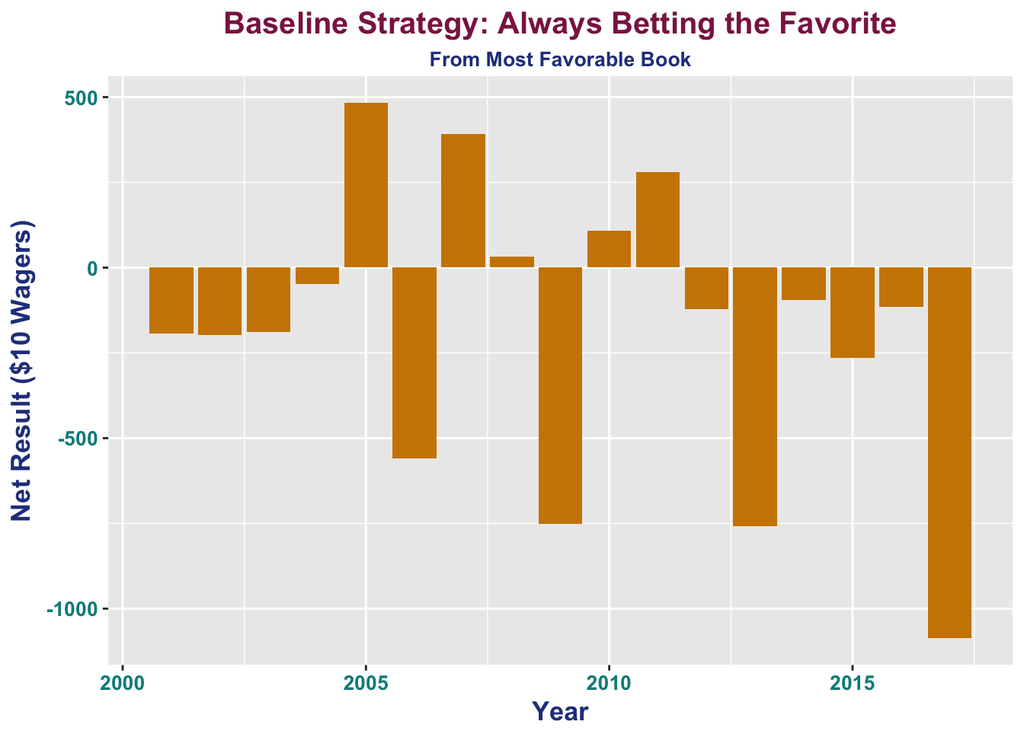

```r
# theme
my.theme <- theme(axis.text.x=element_text(face="bold",color="cyan4", size=10), axis.text.y=element_text(face="bold",color="cyan4",size=10), axis.title = element_text(face="bold",color="royalblue4",size=13), plot.title = element_text(face="bold",color="violetred4",size=15,hjust=.5), legend.title=element_blank(), plot.subtitle = element_text(face="bold", color="royalblue4", size=10, hjust=.5))

# Favorite
ggplot(data=df6, aes(x=Year, y=Net)) + stat_summary(fun.y=mean, geom="bar", fill="orange3") + labs(x="Year", y="Net Result ($10 Wagers)", title="Baseline Strategy: Always Betting the Favorite", subtitle="From Most Favorable Book") + my.theme
```

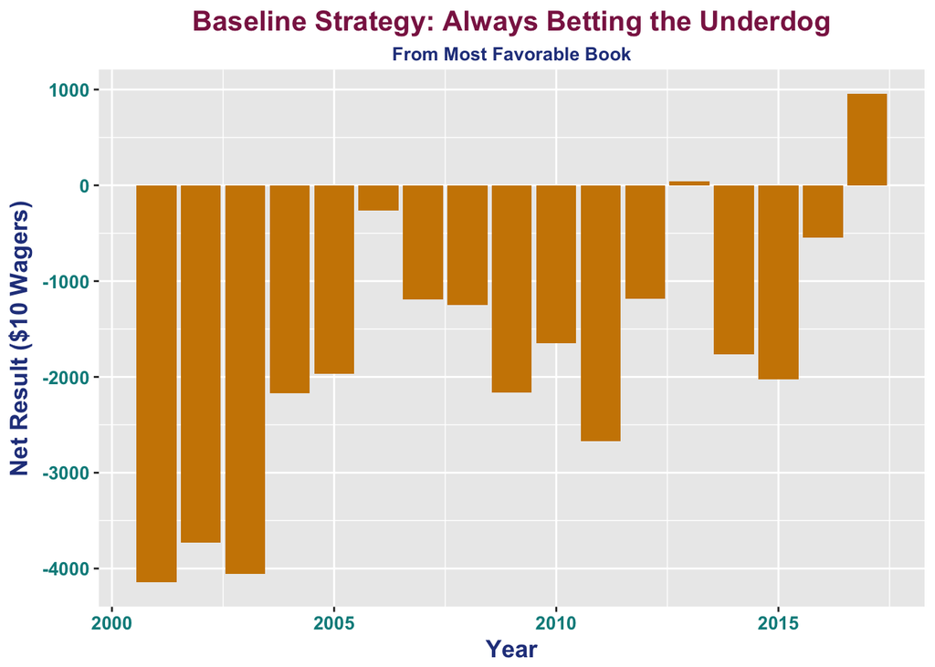

```r
# Underdog
ggplot(data=df7, aes(x=Year, y=Net)) + stat_summary(fun.y=mean, geom="bar", fill="orange3") + labs(x="Year", y="Net Result ($10 Wagers)", title="Baseline Strategy: Always Betting the Underdog", subtitle="From Most Favorable Book") + my.theme
```

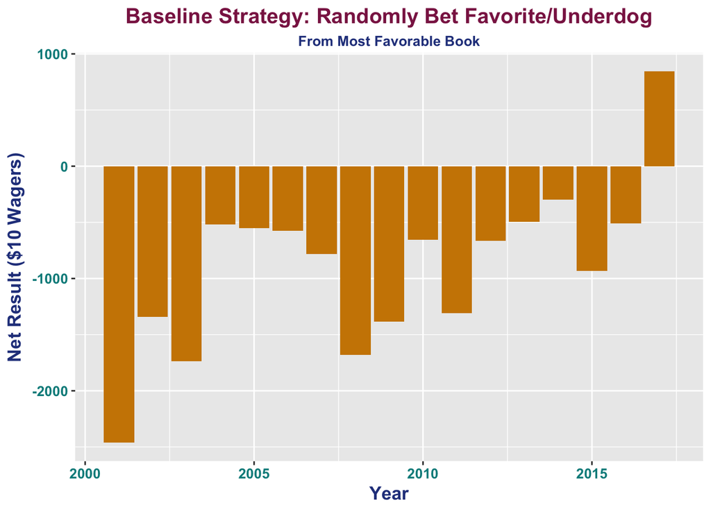

```r
# Random
ggplot(data=df8, aes(x=Year, y=Net)) + stat_summary(fun.y=mean, geom="bar", fill="orange3") + labs(x="Year", y="Net Result ($10 Wagers)", title="Baseline Strategy: Randomly Bet Favorite/Underdog", subtitle="From Most Favorable Book") + my.theme
```

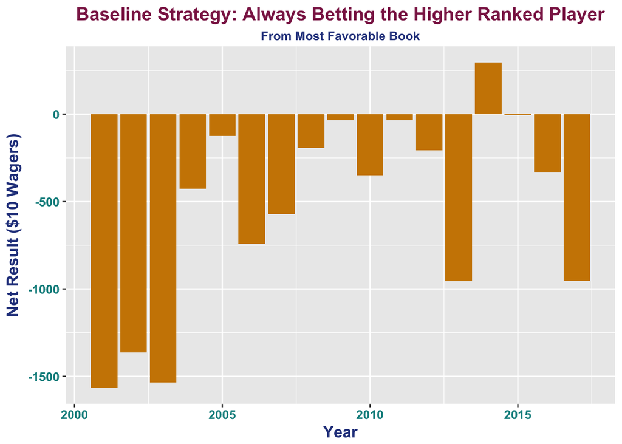

```r
# Higher Rank
ggplot(data=df9, aes(x=Year, y=Net)) + stat_summary(fun.y=mean, geom="bar", fill="orange3") + labs(x="Year", y="Net Result ($10 Wagers)", title="Baseline Strategy: Always Betting the Higher Ranked Player", subtitle="From Most Favorable Book") + my.theme
```

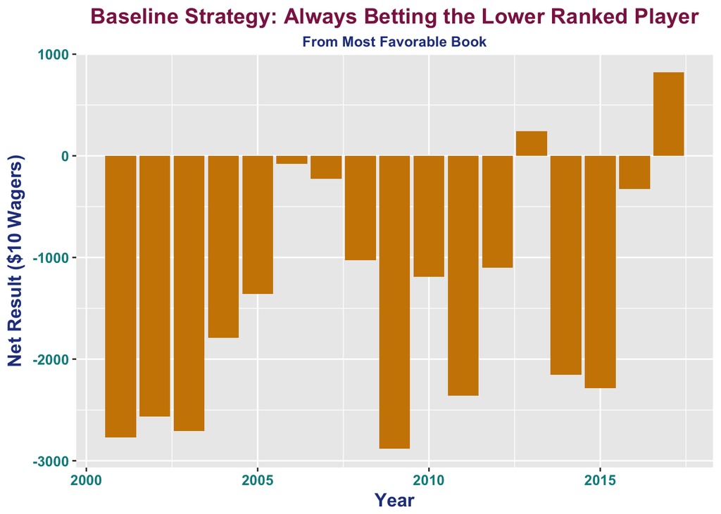

```r
# Lower Rank
ggplot(data=df10, aes(x=Year, y=Net)) + stat_summary(fun.y=mean, geom="bar", fill="orange3") + labs(x="Year", y="Net Result ($10 Wagers)", title="Baseline Strategy: Always Betting the Lower Ranked Player", subtitle="From Most Favorable Book") + my.theme
```

#### Comments on Results

The ultimate conclusion from the baseline strategies: YOU CANNOT WIN WITH THEM… You will lose in the long run. However, betting the favorite is not quite as devastating as betting the underdog.